# The model

Mladen Cucak

24 June, 2019

```r
source(here::here("scr", "pkg.R"))
```

```
## [1] "All packages were successfully loaded."
```

## The Model

### Sporulation

Sporulation is occuring and whether those spores that are produced will be dispersed in the air and we want to know if those sporangia are transported viable or are killed during transport. Solar radiation is lethal to sporangia and most that are in the air will be killed by the sunlight before they reach another location, and subsequentially, how long they might survive on foliage in that location. We do know that on sunny days they don’t survive as well as they do on cloudy days so conceptually we know that the very worst conditions for dispersal ae a sunny morning so that does enhanced release becomes cloudy fairly quickly and midday and that will enhance survival of spores. Wet leaves at night are enabling germination and infection to occur during the night. These factors are put together into an algorithm which includes the amount of sporulation, the survival of this branch and the likelihood that germination will occur on the succeeding evening.This algorithm then provides a Risk estimation.

Rao et al. (1998) showed that LWD estimation on a maze ear was less accurate with weather data measured nearby weather station than near the top of the maze canopy. When estimated weather data are used as input data of an energy balance model, it is considerably difficult for energy balance models to correctly identify wetness occurrence.

```r
spor_df <- read_excel(here::here("dat", "Harrison data.xlsx"))
```

```
## * `` -> ...1
```

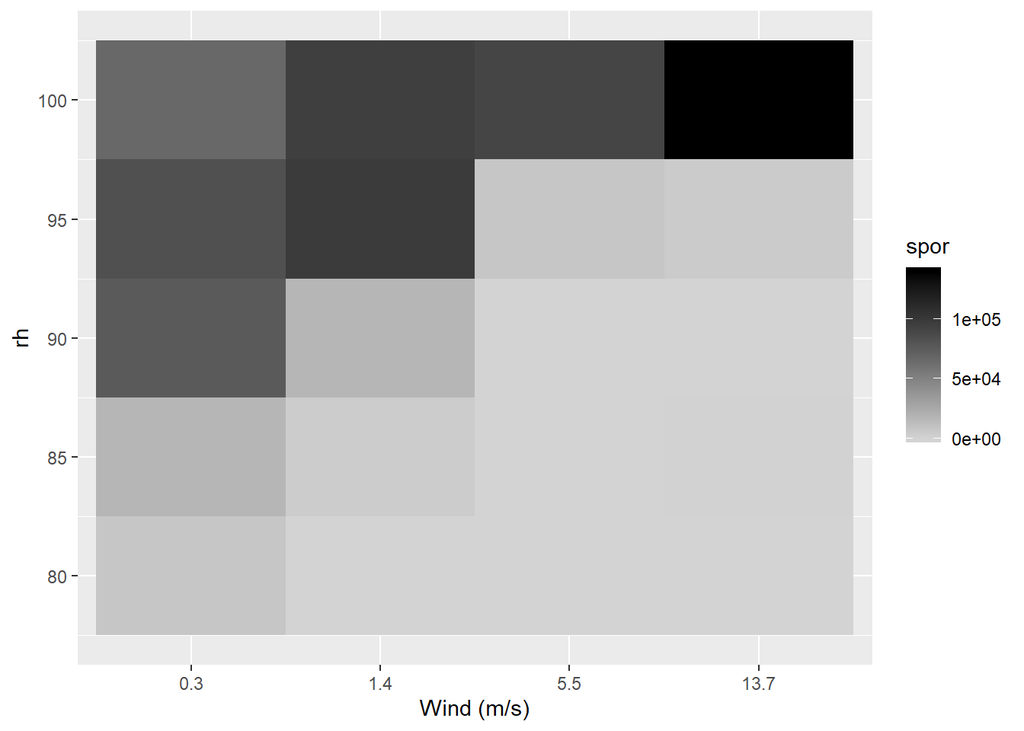

```r
names(spor_df)[1] <- "rh"
spor_df <-  gather(spor_df, "wind", "spor", -rh)
spor_df$spor <-  as.numeric(spor_df$spor)
spor_df$wind <-  as.numeric(spor_df$wind)
# spor_df$wind <-  factor(spor_df$wind, levels = c("0.3", "1.4", "5.5", "13.7"))
ggplot(spor_df, aes(factor(spor_df$wind, levels = c("0.3", "1.4", "5.5", "13.7")), rh))+
  geom_tile(aes(fill = spor))+
  xlab("Wind (m/s)")+
  scale_fill_gradient(low = "lightgray", high = "black")
```

```r
spor_df <-  spor_df[spor_df$wind == 1.4 ,] %>% arrange(., rh)
```

*!!The rate parameter is not good here and this needs refitting*

```r
start_Ks <- c(110) #the population size at equilibrium
start_n0 <- c(0.001) #the population size at the begining
start_r<- c(0.15) #the growth rate
rh <- spor_df$rh - 80
spor <-  spor_df$spor

#Use minpack.lm function because nls apparently has a famouse "singular gradient issue"
  f <- spor~K*n0*exp(r*rh)/(K+n0*(exp(r*rh)-1))
m <-
  minpack.lm::nlsLM(
    formula = f,
    start = list(K = start_Ks, n0 = start_n0, r = start_r),
    control = nls.lm.control(maxiter = 500)
    )
m
```

```
## Nonlinear regression model
##   model: spor ~ K * n0 * exp(r * rh)/(K + n0 * (exp(r * rh) - 1))
##    data: parent.frame()
##         K        n0         r
## 9.705e+04 6.049e-04 1.735e+00
##  residual sum-of-squares: 22310121
##
## Number of iterations till stop: 94
## Achieved convergence tolerance: 1.49e-08
## Reason stopped: Number of calls to `fcn' has reached or exceeded `maxfev' == 400.
```

```r
fit_data <- broom::augment(m)
fit_data[, c("spor", ".fitted")]
```

```
## # A tibble: 5 x 2
##    spor      .fitted
##   <dbl>        <dbl>
## 1    69     0.000605
## 2  4384     3.54
## 3 17147 17073.
## 4 98221 96972.
## 5 95804 97050.
```

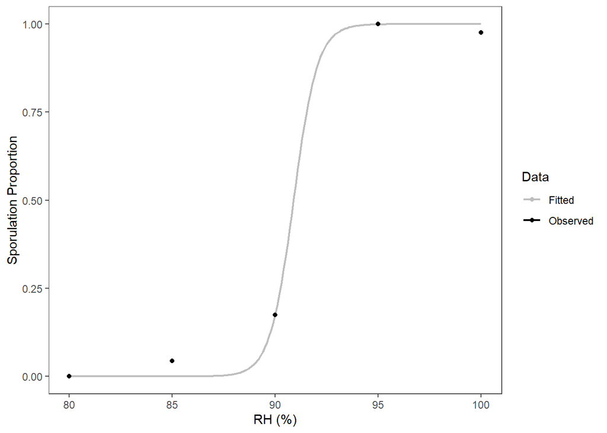

```r
# return rh data to approprate scale
fit_data[, "rh"] <- fit_data[, "rh"] + 80

# Change to a resizing factor, as a proportion
fit_data[, c(".fitted", "spor")] <- lapply(fit_data[, c(".fitted", "spor")], function(x) x/max(x))

#do the same stpes with the predicted data
newdata <- data.frame( rhvec = seq(0, 20, 0.1))
newdata$fit <- predict(m, newdata=data.frame( rh =newdata$rhvec ), interval =  "prediction")
newdata$rhvec <- newdata$rhvec+80

newdata[, "fit"] <- newdata[, "fit"] / max(newdata[, "fit"])

#Save the coefficents
    KSpor <- coef(m)[ "K"]
    n0Spor <- coef(m)["n0"]
    rSpor <- coef(m)["r"]


ggplot() +
  geom_line(data =newdata, aes(rhvec, fit,color = "Fitted"), size = 0.8) +
  geom_point(data = fit_data, aes(rh, spor,color = "Observed")) +
  scale_color_manual(values = c("Fitted" = "gray",
                                "Observed" = "black"))+
  labs(y = "Sporulation Proportion", x = "RH (%)", colour = "Data")+
  egg::theme_article()
```

Temperature relation to sporulation.

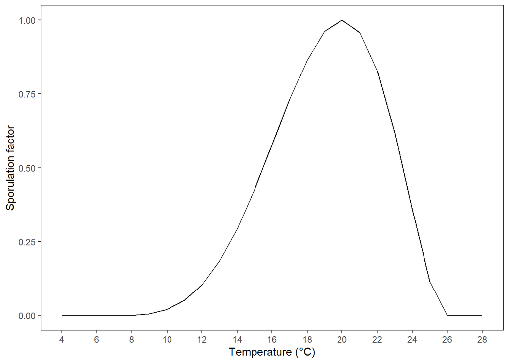

```r
temp <- c(4:28)

TminSpor <- 6
ToptSpor <- 20
TmaxSpor <- 26
RfactSpor <- 1 #set to default 1
ShapeSpor <-2 # parameter that determines the shape of curve

#Function to cacluate the sporulation temperature factor
temp_spor <- sapply(temp, function(x) {
  sporulation_temperature <-
    RfactSpor * ((TmaxSpor - x) / (TmaxSpor - ToptSpor) * ((x - TminSpor) / (ToptSpor - TminSpor)) ^ ((ToptSpor - TminSpor) / (TmaxSpor - ToptSpor))) ^  ShapeSpor
  sporulation_temperature = ifelse(x < TminSpor | x > TmaxSpor, 0, sporulation_temperature)

})
ggplot()+
  geom_line(aes(temp, temp_spor))+
  scale_x_continuous(limits = c(1,30))+
  labs(y = "Sporulation factor",
       x = "Temperature (˚C)")+
  scale_x_continuous(breaks = seq(0,30, 2),labels = seq(0,30, 2))+
  egg:: theme_article()
```

Save parameters into a separate file.

```r
params <- data.frame(
  TminSpor = TminSpor,
  ToptSpor = ToptSpor,
  TmaxSpor = TmaxSpor,
  RfactSpor = RfactSpor,
  ShapeSpor = ShapeSpor,

  KSpor = KSpor,
  n0Spor = n0Spor,
  rSpor = rSpor
)

write_csv(params, here::here("scr", "model", "par", "parameters_sporulation.csv"))
```

Here we put it all into a function. This function calculates the sporulation based on two given vectors containing hourly measurements of reltive humidity and temperature.

```r
Sporulation <-
  function(temp,
           rh,
           parameters) {

    #Import parameters
    #Temp factor
    TminSpor <- parameters[, "TminSpor"]
    ToptSpor <- parameters[, "ToptSpor"]
    TmaxSpor <- parameters[, "TmaxSpor"]
    RfactSpor <- parameters[, "RfactSpor"]
    ShapeSpor <- parameters[, "ShapeSpor"]

    #RH factor
    KSpor <- parameters[, "KSpor"]
    n0Spor <- parameters[, "n0Spor"]
    rSpor <- parameters[, "rSpor"]



    #Calculate temp factor
    #Function to cacluate the sporulation temperature factor
    sporulation_temp <-
    sapply(temp, function(x) {
      sporulation_temperature <-
        RfactSpor * ((TmaxSpor - x) / (TmaxSpor - ToptSpor) * ((x - TminSpor) / (ToptSpor - TminSpor)) ^ ((ToptSpor - TminSpor) / (TmaxSpor - ToptSpor))) ^  ShapeSpor
      sporulation_temperature = ifelse(x < TminSpor | x > TmaxSpor, 0, sporulation_temperature)
      return(sporulation_temperature)
    }) %>% unlist()

    # Calculate the RH factor
    rh <- ifelse(rh >=80, rh - 80, 0) #resize rh scale to 1-20
    sporulation_rh <-
      sapply(rh, function(x) {
      spor_rh_hour <-
      KSpor * n0Spor * exp(rSpor * x) / (KSpor + n0Spor * (exp(rSpor * x) - 1))
      # Change to proportion; sporulation is divided by sporulation at the equilibrium
      spor_rh_hour <-as.numeric(spor_rh_hour)/ as.numeric(KSpor)
      return(spor_rh_hour)
    })

    sporulation <-
      round(sporulation_temp * sporulation_rh, 6)
    return(sporulation)
  }
```

Visualisation of the overal effect of this function.

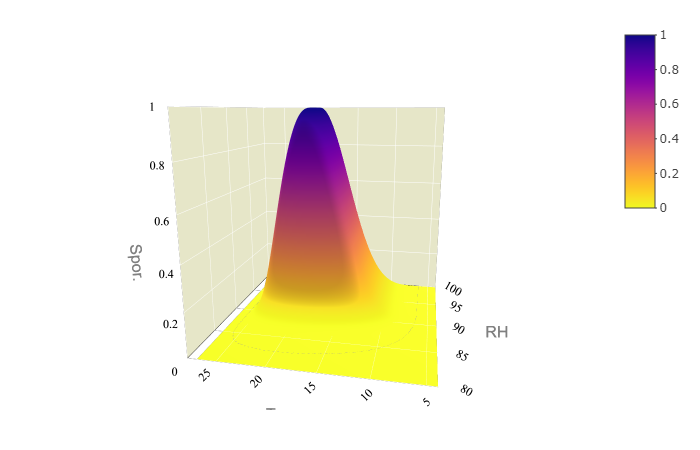

3D surface plot of sporulation function

```r
#Sporulation
require(plotly)

rhum = seq(80,100, 0.1)
temp = seq(4,27, 0.1)

spor <- outer(temp, rhum, Sporulation, params)

f1 <- list(
  family = "Arial, sans-serif",
  size = 16,
  color = "grey"
)
f2 <- list(
  family = "Old Standard TT, serif",
  size = 12,
  color = "black"
)
tit<- list(
  title = "Sporuation Function",
  titlefont = f1,
  tickfont = f2
  )
x <- list(
  title = "RH",
  titlefont = f1,
  showticklabels = TRUE,
  tickangle = 30,
  tickfont = f2,
  exponentformat = "E",
  nticks= 8,
  range= c(80,100),
  backgroundcolor="rgb(230, 230,200)",
  gridcolor="rgb(255,255,255)",
  showbackground=TRUE,
  zerolinecolor="rgb(255,255,255"
)
y <- list(
  title = "Temp",
  titlefont = f1,
  showticklabels = TRUE,
  tickangle = -45,
  tickfont = f2,
  exponentformat = "E",
  nticks = 8,
  range= c(4,28),
  backgroundcolor="rgb(230, 230,200)",
  gridcolor="rgb(255,255,255)",
  showbackground=TRUE,
  zerolinecolor="rgb(255,255,255"
)
z <- list(
  title = "Spor.",
  titlefont = f1,
  showticklabels = TRUE,
  tickangle = 0,
  tickfont = f2,
  exponentformat = "E",
  nticks= 10,
  range= c(0,1),
  backgroundcolor="rgb(230, 230,200)",
  gridcolor="rgb(255,255,255)",
  showbackground=F,
  zerolinecolor="rgb(255,255,255"
)

library(viridis)
color_var <- rev(plasma(256))

p <-
plot_ly(x= rhum,y=temp,z=spor, type="surface",
        colors = color_var) %>%
  layout(
    title = tit,
    scene = list(
      xaxis = x,
      yaxis = y,
      zaxis = z
    ))


##Custom ticks
axx <- list(
  ticketmode = 'array',
  ticktext = c("Huey", "Dewey", "Louie"),
  tickvals = c(0,25,50),
  range = c(-25,75)
)

htmlwidgets::saveWidget(p, "sporulation.html")
```

## Survival

Airborne sporangia survival.

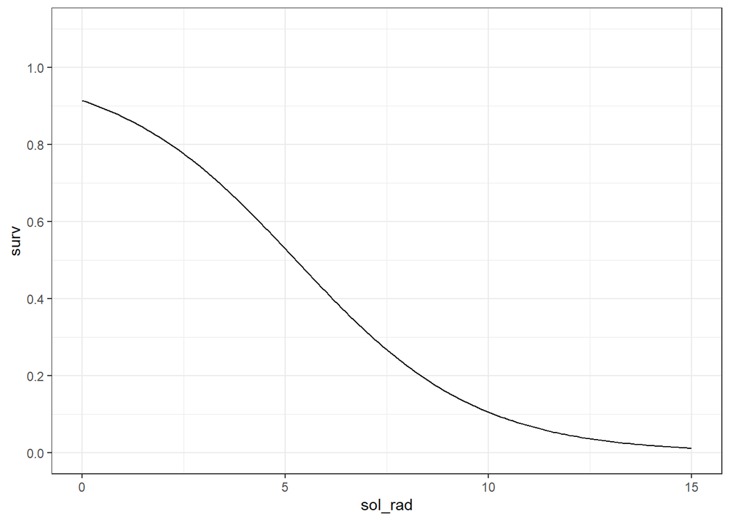

```r
B0 <- 2.37
B1 <- 0.45
Survival <- function(x) {
  Pr <- 1 / (1 + exp(-(B0 - B1 * x)))
}
data.frame(
  sol_rad = seq(0,30, 0.1)
) %>%
  mutate(surv = Survival(sol_rad)) %>%
ggplot()+
  geom_line(aes(sol_rad, surv))+
  scale_y_continuous( limits = c(0,1.1),  breaks = seq(0,1.4,0.2))+
  scale_x_continuous(limits = c(0,15))+
  theme_bw()
```

Save the parameters into a separate file.

```r
params_solsurv <- data.frame(
  B0 = B0,
  B1 = B1
)

write_csv(params_solsurv, here::here("scr", "model", "par", "parameters_sol_surv.csv"))
```

This function calculates the survival probabllty based on sum of total daily sola radiation.

```r
SolSurv <-
  function(sol,
           params_solsurv) {
    B0 <- params_solsurv[, "B0"]
    B1 <- params_solsurv[, "B1"]

    Survival <- function(x) {
      Pr <- 1 / (1 + exp(-(B0 - B1 * x)))
    }

    sol_surv <-  Survival(sol)

    return(round(sol_surv, 6))
  }
```

## Infection

!!!!!!!!!!!!!!!!The Shape factor needs fixing for the sensitivity analysis. ! None of leaf wetness assumptions are fulfilled before the plants form a substantial haulum. The surface wethess on plant surface is an essential requirement for germination or zoospore release and for subsequent infection to take place. Risk of the infection is calculated as a function of temperature and leaf wetness risk factors.  
Temperature effect on Infection is estimated using two functions, one for the direct germinationa and one for zoospore infection. Minimum and maximum values are set equal for both functions.  
The leaf wetness is calculated using two linear functions.

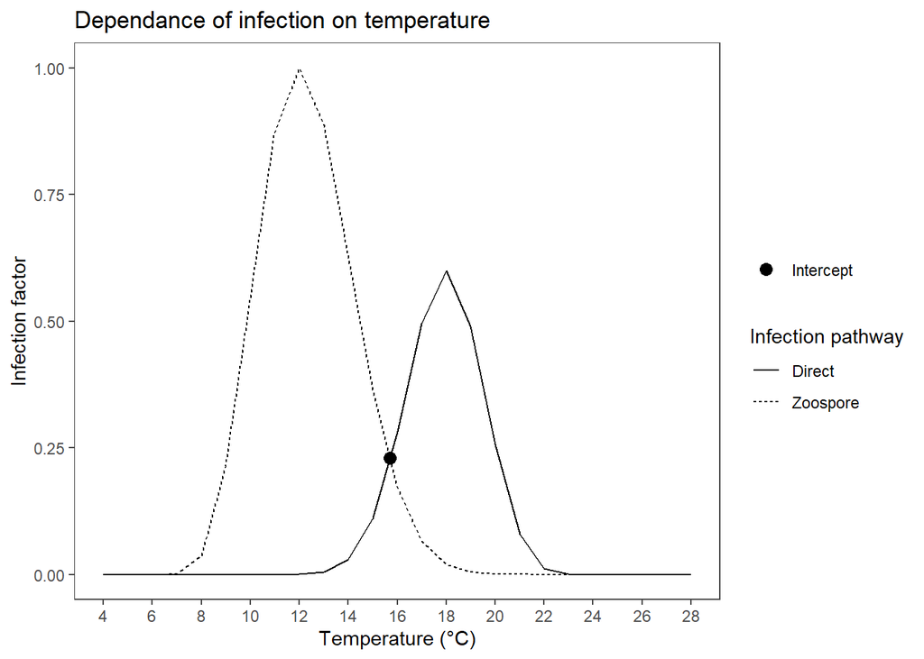

```r
# TODO add the rain to lw
#  Check the newforge data for leaf wetness could it be used?
#

temp <- c(4:28)

#Direct infection function
TminInf <- 6
ToptInf <- 12
TmaxInf <- 26
RfactInf <- 1 #set to default 1
ShapeInf <-15 # parameter that determines the shape of curve


temp_inf_zoo <- sapply(temp, function(x) {
  Infection_temperature <-
    RfactInf * ((TmaxInf - x) / (TmaxInf - ToptInf) * ((x - TminInf) / (ToptInf - TminInf)) ^ ((ToptInf - TminInf) / (TmaxInf - ToptInf))) ^  ShapeInf
  Infection_temperature = ifelse(x < TminInf | x > TmaxInf, 0, Infection_temperature)

})

#Direct infection function
TminInfDir <- 6
ToptInfDir <- 18
TmaxInfDir <- 26
RfactInfDir <- 0.6
ShapeInfDir <-15 # parameter that determines the shape of curve


#Function to cacluate the Infection temperature factor
temp_inf_direct <- sapply(temp, function(x) {
  Infection_temperature <-
    RfactInfDir * ((TmaxInfDir - x) / (TmaxInfDir - ToptInfDir) * ((x - TminInfDir) / (ToptInfDir - TminInfDir)) ^ ((ToptInfDir - TminInfDir) / (TmaxInfDir - ToptInfDir))) ^  ShapeInfDir
  Infection_temperature = ifelse(x < TminInfDir | x > TmaxInfDir, 0, Infection_temperature)

})
# Find the curve intersect
x <- which(temp_inf_zoo==RfactInf) #peek of zoospore germiantion
y <- which(temp_inf_direct==RfactInfDir) #peek of direct germination


# Straight lines (empirical)
line1 <- data.frame(x = temp[x:y], y = temp_inf_direct[x:y])
line2 <- data.frame(x = temp[x:y], y = temp_inf_zoo[x:y])

intersect <-  reconPlots::curve_intersect(line1, line2) %>% as.data.frame()

InterTemp <- intersect[, "x"]

ggplot() +
  geom_line(aes(temp, temp_inf_direct, linetype = "Direct")) +
  geom_line(aes(temp, temp_inf_zoo, linetype = "Zoospore")) +
  scale_linetype("Infection pathway") +
  geom_point(data = intersect, aes(x, y, shape = "Intercept"),  size = 3) +
  scale_shape("") +
  scale_x_continuous(limits = c(1, 30)) +
  labs(title = "Dependance of infection on temperature",
       y = "Infection factor",
       x = "Temperature (˚C)") +
  scale_x_continuous(breaks = seq(0, 30, 2), labels = seq(0, 30, 2)) +
  egg::theme_article()
```

RH factor.  
!!!!!!!!!!!Needs further clarification and explanation expecilly why this exact figure/or just do calibration.

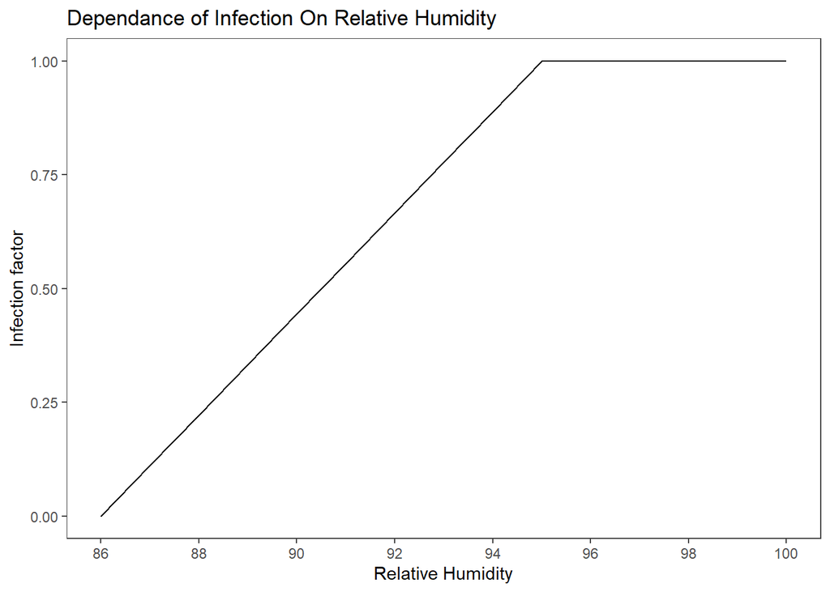

```r
RhminInf <- 86
RhoptInf <- 95

#fit linear model
x <- c(RhminInf, RhoptInf)
coefs <- lm(c(0,1) ~ x )[["coefficients"]]

rhum <- c(RhminInf:100)

inf_rh <- sapply(rhum, function (rhum_val) {
  if (rhum_val > RhminInf & rhum_val <= RhoptInf) {
    SporRh <-  coefs[["(Intercept)"]] +coefs[["x"]] * rhum_val
  } else if (rhum_val > RhoptInf & rhum_val <= 100) {
    SporRh <- 1
  } else {
    SporRh <- 0
  }
})

ggplot()+
  geom_line(aes(rhum, inf_rh))+
  scale_x_continuous(limits = c(1, 30)) +
  labs(title = "Dependance of Infection On Relative Humidity",
       y = "Infection factor",
       x = "Relative Humidity") +
  scale_x_continuous(breaks = seq(RhminInf, 100, 2), labels = seq(RhminInf, 100,2 )) +
  egg::theme_article()
```

Save parameters into a separate file.

```r
params_inf <- data.frame(
  #temperature factor
  TminInf = TminInf,
  ToptInf = ToptInf,
  TmaxInf = TmaxInf,
  RfactInf = RfactInf,
  ShapeInf = ShapeInf,
  # Direct penetrtion
  TminInfDir = TminInf,
  ToptInfDir =  ToptInfDir,
  TmaxInfDir = TmaxInf,
  RfactInfDir = RfactInfDir,
  ShapeInfDir = ShapeInfDir,
  # Temperature intersect between functions for mechanisms of infection
  InterTemp = intersect[ , "x"],

  #rh factor
  RhminInf = RhminInf,
  RhoptInf = RhoptInf
)

write_csv(params_inf, here::here("scr", "model", "par", "parameters_infection.csv"))
```

Here we put it all into a function. This function calculates the infection risk based on two given vectors containing hourly measurements of reltive humidity and temperature.

```r
Infection <-
  function(temp,
           rh,
           params_inf) {

    #Import parameters
    #Temp factor zoospore
    TminInf <- params_inf[, "TminInf"]
    ToptInf <- params_inf[, "ToptInf"]
    TmaxInf <- params_inf[, "TmaxInf"]
    RfactInf <- params_inf[, "RfactInf"]
    ShapeInf <- params_inf[, "ShapeInf"]
    #Temp factor direct
    TminInfDir <- params_inf[, "TminInf"]
    ToptInfDir <- params_inf[, "ToptInfDir"]
    TmaxInfDir <- params_inf[, "TmaxInf"]
    # Temperature intersect between functions for mechanisms of infection
    InterTemp <- params_inf[, "InterTemp"] %>% as.numeric()

    RfactInfDir <- params_inf[, "RfactInfDir"]
    ShapeInfDir <- params_inf[, "ShapeInfDir"]



    #Calculate temp factor
    #Function to cacluate the Infection temperature factor
    temp_inf_zoo <- sapply(temp, function(x) {
      Infection_temperature <-
        RfactInf * ((TmaxInf - x) / (TmaxInf - ToptInf) * ((x - TminInf) / (ToptInf - TminInf)) ^ ((ToptInf - TminInf) / (TmaxInf - ToptInf))) ^  ShapeInf
      Infection_temperature = ifelse(x < TminInf |
                                       x > TmaxInf, 0, Infection_temperature)
    }) %>% unlist()

    #Function to cacluate the Infection temperature factor
    temp_inf_direct <- sapply(temp, function(x) {
      Infection_temperature <-
        RfactInfDir * ((TmaxInfDir - x) / (TmaxInfDir - ToptInfDir) * ((x - TminInfDir) / (ToptInfDir - TminInfDir)) ^ ((ToptInfDir - TminInfDir) / (TmaxInfDir - ToptInfDir))) ^  ShapeInfDir
      Infection_temperature = ifelse(x < TminInfDir |
                                       x > TmaxInfDir, 0, Infection_temperature)
    })%>% unlist()

    inf_temp <-
      ifelse(temp <= InterTemp, temp_inf_zoo, temp_inf_direct )

    #RH factor
    RhminInf <- params_inf[, "RhminInf"]
    RhoptInf <- params_inf[, "RhoptInf"]


    # Calculate the RH factor
    #fit linear model
    x <- c(RhminInf, RhoptInf) %>% as.numeric()
    coefs <- lm(c(0, 1) ~ x)[["coefficients"]]

    inf_rh <- sapply(rh, function (rhum_val) {
      if (rhum_val > RhminInf & rhum_val <= RhoptInf) {
        SporRh <-  coefs[["(Intercept)"]] + coefs[["x"]] * rhum_val
      } else if (rhum_val > RhoptInf & rhum_val <= 100) {
        SporRh <- 1
      } else {
        SporRh <- 0
      }
    })

    infection = round(inf_temp * inf_rh, 6)
    return(infection)
  }
```

Visualisation of the overal effect of this function.

[figure not shown]

3D surface plot of Infection function

```r
#Infection
require(plotly)

rhum = seq(80,100, 0.1)
temp = seq(4,27, 0.1)

inf_ar <- outer(temp, rhum, Infection, params_inf)




f1 <- list(
  family = "Arial, sans-serif",
  size = 16,
  color = "grey"
)
f2 <- list(
  family = "Old Standard TT, serif",
  size = 12,
  color = "black"
)
tit<- list(
  title = "Infuation Function",
  titlefont = f1,
  tickfont = f2
  )
x <- list(
  title = "RH",
  titlefont = f1,
  showticklabels = TRUE,
  tickangle = 30,
  tickfont = f2,
  exponentformat = "E",
  nticks= 8,
  range= c(80,100),
  backgroundcolor="rgb(230, 230,200)",
  gridcolor="rgb(255,255,255)",
  showbackground=TRUE,
  zerolinecolor="rgb(255,255,255"
)
y <- list(
  title = "Temp",
  titlefont = f1,
  showticklabels = TRUE,
  tickangle = -45,
  tickfont = f2,
  exponentformat = "E",
  nticks = 8,
  range= c(4,28),
  backgroundcolor="rgb(230, 230,200)",
  gridcolor="rgb(255,255,255)",
  showbackground=TRUE,
  zerolinecolor="rgb(255,255,255"
)
z <- list(
  title = "Infection",
  titlefont = f1,
  showticklabels = TRUE,
  tickangle = 0,
  tickfont = f2,
  exponentformat = "E",
  nticks= 10,
  range= c(0,1),
  backgroundcolor="rgb(230, 230,200)",
  gridcolor="rgb(255,255,255)",
  showbackground=F,
  zerolinecolor="rgb(255,255,255"
)

library(viridis)
color_var <- rev(plasma(256))

p <-
plot_ly(x= rhum,y=temp,z=inf_ar, type="surface",
        colors = color_var) %>%
  layout(
    title = tit,
    scene = list(
      xaxis = x,
      yaxis = y,
      zaxis = z
    ))


##Custom ticks
axx <- list(
  ticketmode = 'array',
  ticktext = c("Huey", "Dewey", "Louie"),
  tickvals = c(0,25,50),
  range = c(-25,75)
)

htmlwidgets::saveWidget(p, "Infection.html")
```

# Geo location

```r
#https://github.com/cran/HelpersMG/blob/master/R/sun.info.R


SunInfo <- function(date, latitude, longitude,
                     #Ireland uses Irish Standard Time (IST, UTC+01:00 in the summer months
                     #and Greenwich Mean Time (UTC+0) in the winter period.
                     UTC_zone
                     ){

  d <- as.numeric(as.POSIXlt(date)$yday)+1
  Lat <- latitude
  Long <- longitude

  ## d is the day of year
  ## Lat is latitude in decimal degrees
  ## Long is longitude in decimal degrees (negative == West)

  ##This method is copied from:
  ##Teets, D.A. 2003. Predicting sunrise and sunset times.
  ##  The College Mathematics Journal 34(4):317-321.

  ## At the default location the estimates of sunrise and sunset are within
  ## seven minutes of the correct times (http://aa.usno.navy.mil/data/docs/RS_OneYear.php)
  ## with a mean of 2.4 minutes error.

  ## Function to convert degrees to radians
  rad <- function(x) pi*x/180

  ##Radius of the earth (km)
  R=6378

  ##Radians between the xy-plane and the ecliptic plane
  epsilon=rad(23.45)

  ##Convert observer's latitude to radians
  L=rad(Lat)

  ## Calculate offset of sunrise based on longitude (min)
  ## If Long is negative, then the mod represents degrees West of
  ## a standard time meridian, so timing of sunrise and sunset should
  ## be made later.
  timezone = -4*(abs(Long)%%15)*sign(Long)

  ## The earth's mean distance from the sun (km)
  r = 149598000

  theta = 2*pi/365.25*(d-80)

  z.s = r*sin(theta)*sin(epsilon)
  r.p = sqrt(r^2-z.s^2)

  t0 = 1440/(2*pi)*acos((R-z.s*sin(L))/(r.p*cos(L)))

  ##a kludge adjustment for the radius of the sun
  that = t0+5

  ## Adjust "noon" for the fact that the earth's orbit is not circular:
  n = 720-10*sin(4*pi*(d-80)/365.25)+8*sin(2*pi*d/365.25)

  ## now sunrise and sunset are:
  sunrise = (n-that+timezone)/60
  sunset = (n+that+timezone)/60

  UTC <- (((7.5+Long)%%360)) %/% 15
  if (UTC>12) {UTC <- 12-UTC;tz <- "Etc/GMT"} else {tz <- "Etc/GMT+"}
  tz <- paste0(tz, UTC)

  df <-
    data.frame(
      sunrise = sunrise,
      sunset = sunset,
      day.length = sunset - sunrise,
      date.time.sunrise = as.POSIXlt(format(date, "%Y-%m-%d"), tz =
                                       tz) + sunrise * 60 * 60,
      date.time.sunset = as.POSIXlt(format(date, "%Y-%m-%d"), tz =
                                      tz) + sunset * 60 * 60
    )

  sunrise.UTC <-
    as.POSIXlt(
      format(df$date.time.sunrise, format = "%Y-%m-%d %H:%M:%S"),
      tz = "UTC",
      use.tz = TRUE
    )
  sunrise.UTC.dec <-
    sunrise.UTC$hour + sunrise.UTC$min / 60 + sunrise.UTC$sec / 3600
  sunset.UTC <-
    as.POSIXlt(
      format(df$date.time.sunset, format = "%Y-%m-%d %H:%M:%S"),
      tz = "UTC",
      use.tz = TRUE
    )
  sunset.UTC.dec <-
    sunset.UTC$hour + sunset.UTC$min / 60 + sunset.UTC$sec / 3600

  #Return
  df <-
    data.frame(
      # df,
      sunrise = sunrise.UTC + c(UTC_zone*60*60),
      sunset = sunset.UTC  + c(UTC_zone*60*60)
      # time.sunrise.UTC = sunrise.UTC.dec,
      # time.sunset.UTC = sunset.UTC.dec
    )

  return(df)
}
```

```r
params_time <- data.frame(
  hr_before_spor = 5,
  hr_after_spor = 5,
  hr_after_inf = 2
)

write_csv(params_time, here::here("scr", "model", "par", "parameters_time.csv"))
```

```r
GetTimes <- function(fun_df, params_time) {

  hr_before_spor <- params_time[, "hr_before_spor"]
  hr_after_spor <- params_time[, "hr_after_spor"]
  hr_after_inf <- params_time[, "hr_after_inf"]

  # Set the sunset and sunrise manually at 20/6
  # fun_df[fun_df$hour == 20, "daytime"] <- "sunset"
  # fun_df[fun_df$hour == 6, "daytime"] <- "sunrise"
  if(all(str_detect(colnames(fun_df), fixed("lon", ignore_case=TRUE)))){  stop("No Longitude reference or it is not named: 'lon'!")}
  if(all(str_detect(colnames(fun_df), fixed("lat", ignore_case=TRUE)))){  stop("No Latitude reference or it is not named: 'lat'!")}
  lat <- fun_df[, str_detect(colnames(fun_df), fixed("lat", ignore_case=TRUE))]
  lon <- fun_df[, str_detect(colnames(fun_df), fixed("lon", ignore_case=TRUE))]

  #Extract dates and geo-coordinates
  tempdf <-
    data.frame(
      date = unique(fun_df$short_date),
      lat = unique(lat),
      lon = unique(lat)
    )

  lss <-  list()
  for (i in seq_along(1:nrow(tempdf))) {
    lss[[i]] <- SunInfo(tempdf[i,"date"], tempdf[i, "lat"], tempdf[i,"lon"],1)
  }

  tempdf <-
    lss %>%
    bind_rows() %>%
    bind_cols(tempdf, .) %>%
    mutate(sunset_hr = lubridate::hour(sunset),
           sunrise_hr = lubridate::hour(sunrise),
           doy = lubridate::yday(date)) %>%
    select(c("doy", "sunrise_hr", "sunset_hr"))

  #Retun sunset and sunrise times as a data frame
  return(tempdf)

}
```